# Most harmful storm events

Oleksandr Fialko

11/20/2016

## Introduction

Storms and other severe weather events can cause both public health and economic problems for communities and municipalities. Many severe events can result in fatalities, injuries, and property damage, and preventing such outcomes to the extent possible is a key concern.

This project involves exploring the U.S. National Oceanic and Atmospheric Administration’s (NOAA) storm database. This database tracks characteristics of major storms and weather events in the United States, including when and where they occur, as well as estimates of any fatalities, injuries, and property damage.

## Summary

This analysis addresses two questions:

- which types of events are most harmful to population health?
- which types of events have the greatest economic consequences?

## Data Processing

Loading data into R:

```r
storm_data <- read.csv('repdata-data-StormData.csv.bz2',header = T,sep = ',')
dim(storm_data)
```

```
## [1] 902297     37
```

Examining the column names of the dataset:

```r
col_names <- names(storm_data)
col_names
```

```
##  [1] "STATE__"    "BGN_DATE"   "BGN_TIME"   "TIME_ZONE"  "COUNTY"
##  [6] "COUNTYNAME" "STATE"      "EVTYPE"     "BGN_RANGE"  "BGN_AZI"
## [11] "BGN_LOCATI" "END_DATE"   "END_TIME"   "COUNTY_END" "COUNTYENDN"
## [16] "END_RANGE"  "END_AZI"    "END_LOCATI" "LENGTH"     "WIDTH"
## [21] "F"          "MAG"        "FATALITIES" "INJURIES"   "PROPDMG"
## [26] "PROPDMGEXP" "CROPDMG"    "CROPDMGEXP" "WFO"        "STATEOFFIC"
## [31] "ZONENAMES"  "LATITUDE"   "LONGITUDE"  "LATITUDE_E" "LONGITUDE_"
## [36] "REMARKS"    "REFNUM"
```

## Most harmful event to population health

Health related columns are `FATALITIES` and `INJURIES`:

```r
str(storm_data$FATALITIES)
```

```
##  num [1:902297] 0 0 0 0 0 0 0 0 1 0 ...
```

```r
str(storm_data$INJURIES)
```

```
##  num [1:902297] 15 0 2 2 2 6 1 0 14 0 ...
```

`TORNADO` appears to be the most harmful event causing most fatalities and injuries:

```r
fatalities_event <- tapply(storm_data$FATALITIES, storm_data$EVTYPE, sum)
injuries_event <- tapply(storm_data$INJURIES, storm_data$EVTYPE, sum)
most_fatal_event <- fatalities_event[which.max(fatalities_event)]
most_injury_event <- injuries_event[which.max(injuries_event)]
print(paste('Most fatal event is',names(most_fatal_event),'with',most_fatal_event[1],'fatalities',sep = ' '))
```

```
## [1] "Most fatal event is TORNADO with 5633 fatalities"
```

```r
print(paste('Event causing most injuries is',names(most_injury_event),'with',most_injury_event[1],'injuries',sep = ' '))
```

```
## [1] "Event causing most injuries is TORNADO with 91346 injuries"
```

We combine `INJURIES` and `FATALITIES` for each event in one sorted data frame with the total contribution:

```r
df1 <- data.frame(Event = names(fatalities_event), Fatalities_count = fatalities_event)
df2 <- data.frame(Event = names(injuries_event), Injuries_count = injuries_event)
df_merged <- merge(df1,df2,by='Event')
df_merged$Count <- df_merged$Fatalities_count + df_merged$Injuries_count
df_merged$Count <- df_merged$Count/sum(df_merged$Count)
indx = order(df_merged$Count,decreasing = T)
df <- df_merged[indx,]
```

We visualize the contributions from several most harmful events via bar plot:

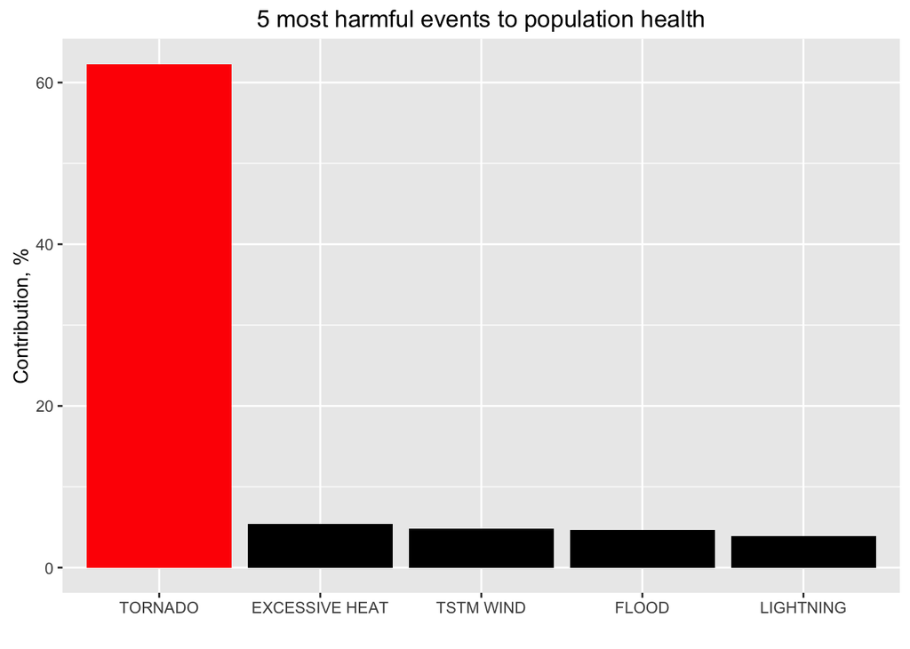

```r
library(ggplot2)

df <- transform(df,Event=factor(Event,levels = Event),Count = 100*Count)
ggplot(df[1:5,],aes(x=Event,y=Count)) + geom_bar(stat = 'identity',fill=c('red',rep('black',4)))+
    labs(title='5 most harmful events to population health')+xlab('')+ylab('Contribution, %')
```

## Event with the greatest economic consequences

Here we are interested in `PROPDMG` and `CROPDMG` variables. We repeat the above analysis but with respect to these new variables.

```r
prop_event <- tapply(storm_data$PROPDMG, storm_data$EVTYPE, sum,na.rm=T)
crop_event <- tapply(storm_data$CROPDMG, storm_data$EVTYPE, sum,na.rm=T)
most_prop_event <- prop_event[which.max(prop_event)]
most_crop_event <- crop_event[which.max(crop_event)]
print(paste('Most property damages are caused by ',names(most_prop_event),'with',most_prop_event[1],'damages',sep = ' '))
```

```
## [1] "Most property damages are caused by  TORNADO with 3212258.16 damages"
```

```r
print(paste('Most crop damages are caused by ',names(most_crop_event),'with',most_crop_event[1],'damages',sep = ' '))
```

```
## [1] "Most crop damages are caused by  HAIL with 579596.28 damages"
```

We create two data frames for `PROPDMG` and `CROPDMG` respectively

```r
df1 <- data.frame(Event = names(prop_event), Count = prop_event/sum(prop_event))
indx <- order(df1$Count,decreasing = T); df1 <- df1[indx,]
df1 <- transform(df1,Event=factor(Event,levels = Event),Count = 100*Count)
df2 <- data.frame(Event = names(crop_event), Count = crop_event/sum(crop_event))
indx <- order(df2$Count,decreasing = T); df2 <- df2[indx,]
df2 <- transform(df2,Event=factor(Event,levels = Event),Count = 100*Count)
```

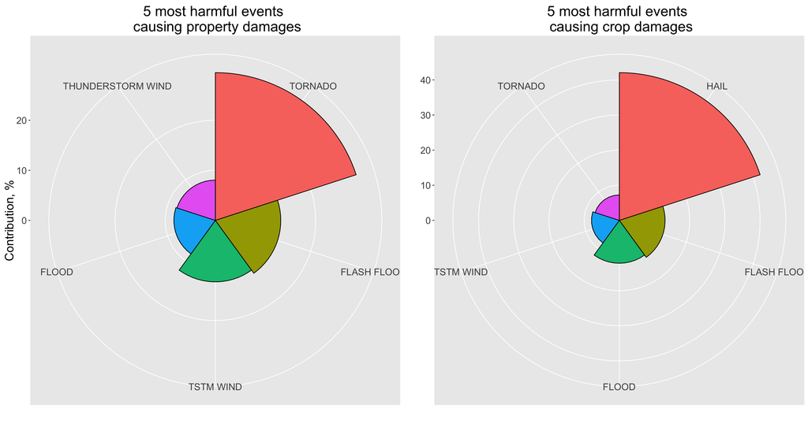

```r
library(ggplot2)
library(gridExtra)
plot1 <- ggplot(df1[1:5,], aes(x = Event,y=Count)) +
    geom_bar(width = 1, colour = "black",stat = 'identity',aes(fill=Event)) +
    xlab('')+ylab('Contribution, %')+
    labs(title='5 most harmful events \n causing property damages')+
    coord_polar()+theme(legend.position='none',text=element_text(size=18))
plot2 <- ggplot(df2[1:5,], aes(x = Event,y=Count)) +
    geom_bar(width = 1, colour = "black",stat = 'identity',aes(fill=Event)) +
    xlab('')+ylab('')+
    labs(title='5 most harmful events \n causing crop damages')+
    coord_polar()+theme(legend.position='none',text=element_text(size=18))
grid.arrange(plot1,plot2,ncol=2)
```

## Results

Storm events are devastating causing injuries, fatalities and lead to great economic consequences. It appears that `TORNADO` is the most harmful to population health and causes the most properties damages, while `HAIL` causes the most crops damages.